# DATAT WARE House and DATA Lake

### Content

1. Data warehouse
   - Architecture
   - Types of warehouses or Data Warehouse Models
   - Data warehouse and database
   - Process of managing database
2. New Data warehouse Architecture
   - Data Warehouse and Data Lake
   - Data Warehouse and Data mart

## Definition of dataware house

[figure not shown]

[figure not shown]

(OLAP: Online analytical processing are used to access the data from the data warehouse.)

Which can be further extended to following figure:

[figure not shown]

### Characteristics and Purposes

Here are the key characteristics and purposes of a data warehouse:

1. **Data Integration:** Data warehouses consolidate data from different operational systems, databases, and external sources. This integration ensures that data from various departments and functions is stored in a standardized and consistent format.
2. **Historical Data:** Data warehouses typically store historical data over extended periods, allowing users to analyze trends and make informed decisions based on historical performance. Operational data or legacy data are the data coming for all possible data source and we can consider them a raw data and they are kept separetly so that they remain untouched i,e, uncorreputed.
3. **Query and Analysis:** Data warehouses provide powerful query and analysis capabilities. Users, such as data analysts and business professionals, can retrieve and analyze data using SQL or specialized BI tools to gain insights into business operations.
4. **Structured Schema:** Data in a data warehouse is organized using a structured schema, often following modeling techniques like Star Schema or Snowflake Schema. This schema design facilitates efficient querying and reporting.
5. **Data Quality:** Data quality is a critical aspect of data warehousing. Measures are taken to ensure data accuracy, consistency, and reliability.
6. **Separation from Transactional Systems:** Data warehouses are distinct from the operational databases used in day-to-day business operations. This separation ensures that analytical queries do not impact the performance of operational systems.
7. **Scalability:** Data warehouses are designed to handle large volumes of data and can be scaled both vertically (adding more resources to a single server) and horizontally (adding more servers) to accommodate growing data needs.
8. **Business Intelligence (BI):** Data warehouses serve as the foundation for BI tools and reporting platforms. Users can create dashboards, reports, and visualizations based on the data stored in the warehouse.
9. **Data Governance:** Data warehouses often incorporate data governance policies and procedures to manage data access, security, and compliance with regulatory requirements.
10. **Performance Optimization:** Data warehouses employ various optimization techniques to ensure fast query performance, including indexing, caching, and parallel processing.

Common technologies used for implementing data warehouses include Amazon Redshift, Google BigQuery, Snowflake, Microsoft Azure SQL Data Warehouse, and on-premises solutions like Teradata and Oracle Exadata.

In summary, a data warehouse is a central repository that enables organizations to store, manage, and analyze their data efficiently, providing valuable insights for decision-making processes and business improvement.

### How does a data warehouse work?

- A data warehouse may contain multiple databases.
- Within each database, data is organized into tables and columns.
- Within each column, you can define a description of the data, such as integer, data field, or string.
- Tables can be organized inside of schemas, which you can think of as folders.
- When data is ingested, it is stored in various tables described by the schema.
- Query tools use the schema to determine which data tables to access and analyze.

### Architecture

Generally speaking, data warehouses have a three-tier architecture, which consists of a:

- **Bottom tier:** The bottom tier consists of a data warehouse server, usually a relational database system, which collects, cleanses, and transforms data from multiple data sources through a process known as Extract, Transform, and Load (ETL) or a process known as Extract, Load, and Transform (ELT).
- **Middle tier:** The middle tier consists of an OLAP (i.e. online analytical processing) server which enables fast query speeds. Three types of OLAP models can be used in this tier, which are known as:
  - ROLAP,
  - MOLAP and
  - HOLAP.

  The type of OLAP model used is dependent on the type of database system that exists.
- **Top tier:** The top tier is represented by some kind of front-end user interface or reporting tool, which enables end users to conduct ad-hoc data analysis on their business data and presents results through reporting, analysis, and data mining tools.

### Types of warehouses or Data Warehouse Models

There are different types of data warehouses based on their architecture and purpose. Some common examples include:

- **Enterprise Data Warehouse (EDW):** An EDW serves as the central repository for all organizational data, integrating data from various sources across the entire enterprise. It provides a comprehensive view of the business and supports enterprise-wide reporting and analysis.
- **Operational Data Store (ODS):** An ODS is a database that contains real-time or near-real-time data from multiple operational systems. It acts as an intermediate layer between operational systems and the data warehouse, providing more immediate access to data for operational reporting and monitoring.
- **Data Mart:** A data mart is a subset of a data warehouse focused on a specific business function, department, or user group. It contains a tailored set of data and is designed to address the specific analytical needs of a particular business area, such as sales, marketing, or finance.
- **Virtual Data Warehouse (VDW):** A VDW is a concept where data from different sources is virtually integrated and presented as a unified view without physically storing the data in a single location. It provides a logical abstraction layer for querying and analysis, enabling organizations to leverage data from multiple sources without the need for physical consolidation.

### Benefits of using a data warehouse

Benefits of a data warehouse include the following:

- **Better data quality:** A data warehouse centralizes data from a variety of data sources, such as transactional systems, operational databases, and flat files. It then cleanses it, eliminates duplicates, and standardizes it to create a single source of the truth.
- **Faster, business insights:** Data from disparate sources limit the ability of decision makers to set business strategies with confidence. Data warehouses enable data integration, allowing business users to leverage all of a company’s data into each business decision.
- **Smarter decision-making:** A data warehouse supports large-scale BI functions such as data mining (finding unseen patterns and relationships in data), artificial intelligence, and machine learning—tools data professionals and business leaders can use to get hard evidence for making smarter decisions in virtually every area of the organization, from business processes to financial management and inventory management
- **Gaining and growing competitive advantage:** All of the above combine to help an organization finding more opportunities in data, more quickly than is possible from disparate data stores.

## Datalake

A data lake is a centralized repository that stores all your structured and unstructured data at any scale. You can store your data as-is, without having to structure the data, and run different types of analytics—from dashboards and visualizations to big data processing, real-time analytics, and machine learning to guide better decisions.

Data lakes are often used in conjunction with data warehouses, but they are not the same thing. A data warehouse is a structured data store that is optimized for querying and reporting on historical data. A data lake, on the other hand, is a scalable and flexible data store that can store any type of data, regardless of its structure.

[figure not shown]

### Benefits

Some of the benefits of using a data lake include:

- **Scalability:** Data lakes can scale to store any amount of data.
- **Flexibility:** Data lakes can store any type of data, regardless of its structure.
- **Performance:** Data lakes can be optimized for different types of analytics, including batch processing, real-time analytics, and machine learning.
- **Cost-effectiveness:** Data lakes can be more cost-effective than traditional data warehouses, especially for storing large amounts of data.

### Chalanges

Some of the challenges of using a data lake include:

- **Complexity:** Data lakes can be more complex to manage and maintain than traditional data warehouses.
- **Security:** Data lakes need to be properly secured to protect sensitive data.
- **Governance:** Data lakes need to be properly governed to ensure that data is used in a responsible and ethical manner.

Overall, data lakes are a powerful tool for storing and analyzing large amounts of data. They can be used to support a wide range of business applications, including customer intelligence, fraud detection, and product development.

## Applications

Here are some examples of how data lakes are being used in the real world:

- **Retail:** Retailers use data lakes to store and analyze customer data, product data, and sales data. This data can be used to improve customer targeting, product recommendations, and inventory management.
- **Finance:** Financial institutions use data lakes to store and analyze customer data, transaction data, and market data. This data can be used to improve risk management, fraud detection, and investment decisions.
- **Healthcare:** Healthcare organizations use data lakes to store and analyze patient data, medical research data, and clinical trial data. This data can be used to improve patient care, develop new treatments, and reduce costs.

Data lakes are a powerful tool for storing and analyzing large amounts of data. They can be used to support a wide range of business applications, and they are becoming increasingly important as the amount of data that businesses collect and store continues to grow.

### Data warehouse vs. database, data lake, and data mart

| Aspect | Data Warehouse | Database | Data Lake | Data Mart |
| --- | --- | --- | --- | --- |
| **Purpose** | Designed for analytical processing. | Designed for transactional data management. | Designed for storing raw, unstructured data. | Subset of a data warehouse focused on specific business areas. |
| **Data Type** | Contains integrated and historical data. | Typically contains structured, transactional data. | Stores raw and structured, semi-structured, or unstructured data. | Contains summarized and pre-aggregated data for specific use cases. |
| **Data Structure** | Typically follows a structured schema (Star Schema or Snowflake Schema). | Follows a normalized schema (relational database model). | Schema-on-read, allowing flexible data structures. | Follows a dimensional model (Star Schema) for ease of reporting. |
| **Schema Design** | Optimized for query performance. | Optimized for efficient data storage and retrieval. | Flexible schema, data can be ingested without predefined structure. | Designed for ease of reporting and analysis. |
| **Query and Analytics** | Designed for complex data analysis and reporting. | Supports simple queries and transactional operations. | Suitable for ad-hoc queries and big data analytics. | Optimized for specific business units or departments' analytics. |
| **Data Integration** | Integrates data from various sources for a unified view. | Typically focuses on data from a single application or system. | Supports data from various sources with varying structures. | Integrates data relevant to a specific business area. |
| **Performance Optimization** | Utilizes indexing, caching, and parallel processing. | Optimized for ACID (Atomicity, Consistency, Isolation, Durability) properties. | Performance tuning is performed during data processing. | Designed for fast query response times for specific use cases. |
| **Scalability** | Scalable both vertically and horizontally to handle large data volumes. | Scalability depends on the database system; typically vertical scaling. | Scales horizontally to accommodate growing data needs. | Scales according to the needs of the specific business area. |
| **Tools and Technologies** | Uses specialized data warehousing solutions (e.g., Redshift, BigQuery). | Utilizes relational database management systems (e.g., Oracle, MySQL). | Utilizes distributed storage systems (e.g., Hadoop, Azure Data Lake Storage). | May use BI tools for reporting and analytics. |
| **Use Cases** | Business intelligence, reporting, complex analytics. | Transactional applications, e-commerce, record-keeping. | Big data analytics, data science, machine learning. | Department-specific analytics, budgeting, and forecasting. |

### Data Warehouse and Data Lake

- Both data warehouses and data lakes are used to store big data . However, they are very different storage systems.
- A data warehouse stores data that has been formatted for a specific purpose, while a data lake stores data in its raw, unprocessed state, whose purpose is not yet defined.
- Data warehouses and data lakes often complement each other. For example, if raw data stored in a data lake is needed to answer a business question, it can be extracted, cleaned, transformed, and used in a data warehouse for analysis. Data volume, database performance, and storage prices all play an important role in choosing the right storage solution.

[figure not shown]

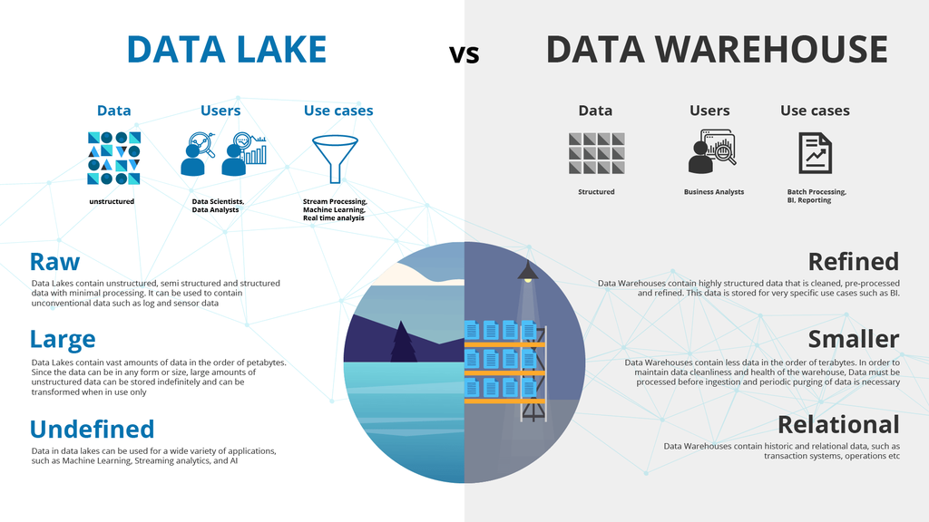

(Image credit: https://www.qubole.com/data-lakes-vs-data-warehouses-the-co-existence-argument)

### Data warehouse and data mart

- A data mart is a subsection of a data warehouse that is separated specifically for a department or line of business—such as sales, marketing, or finance.
- Some data marts are also created for standalone operational purposes. While a data warehouse serves as a central data store for an entire company, a data mart provides relevant data for a select group of users.
- This simplifies data access, speeds up analysis and puts you in control of your own data. Multiple data marts are often set up in a data warehouse.

[figure not shown]

### How do data warehouses, databases, and data lakes work together?

Typically, businesses use a combination of a database, a data lake, and a data warehouse to store and analyze data. Amazon Redshift’s lake house architecture makes such an integration easy.

As the volume and variety of data increases, it’s advantageous to follow one or more common patterns for working with data across your database, data lake, and data warehouse:

[figure not shown]

or

[figure not shown]

(Image credit: https://aws.amazon.com/data-warehouse/)

- A data warehouse is specially designed for data analytics, which involves reading large amounts of data to understand relationships and trends across the data. A database is used to capture and store data, such as recording details of a transaction.
- Unlike a data warehouse, a data lake is a centralized repository for all data, including structured, semi-structured, and unstructured. A data warehouse requires that the data be organized in a tabular format, which is where the schema comes into play. The tabular format is needed so that SQL can be used to query the data. But not all applications require data to be in tabular format. Some applications, like big data analytics, full text search, and machine learning, can access data even if it is ‘semi-structured’ or completely unstructured.

### Tools used to intergrate the warehouses, databases, and data lakes

Integrating data warehouses, databases, and data lakes often involves a combination of tools and technologies to facilitate data movement, transformation, and synchronization across these components. Here are some commonly used tools and methods for integrating them:

1. **ETL (Extract, Transform, Load) Tools:**
   - ETL tools are designed to extract data from source systems, transform it into the desired format, and load it into a target system, which can be a data warehouse, database, or data lake.
   - **Popular ETL tools include**
     - Apache NiFi,
     - Talend,
     - Informatica PowerCenter,
     - Microsoft SQL Server Integration Services (SSIS), and
     - Apache Spark

       for batch and stream processing.
2. **Data Integration Platforms:**
   - These platforms provide a comprehensive solution for data integration, including data profiling, cleansing, transformation, and loading.
   - Examples include
     - Apache Nifi,
     - Apache Camel, and
     - Apache Kafka

       for stream processing.
3. **Data Integration Middleware:**
   - Middleware solutions facilitate communication and data transfer between different systems, including data warehouses, databases, and data lakes.
   - **Tools:**
     - Apache Kafka,
     - RabbitMQ, and
     - Apache Pulsar

       are often used for real-time data streaming and messaging.
4. **Data Replication Tools:**
   - Data replication tools enable real-time or near-real-time data synchronization between databases and data warehouses.
   - **Solutions:**
     - Oracle GoldenGate,
     - AWS Database Migration Service, and
     - Microsoft Azure Data Factory

       offer data replication capabilities.
5. **Data Virtualization Tools:**
   - Data virtualization allows organizations to create a unified, virtual view of data spread across different sources without physically moving it.
   - **Tools:**
     - Denodo,
     - Informatica Enterprise Data Catalog, and
     - Red Hat JBoss Data Virtualization

       offer data virtualization capabilities.
6. **APIs and Web Services:**
   - APIs (Application Programming Interfaces) and web services can be used to exchange data between systems programmatically.
   - RESTful APIs, SOAP APIs, and GraphQL are common protocols for data integration via web services.
7. **Custom Scripting and Coding:**
   - For highly customized integration requirements, organizations may develop custom scripts or code using programming languages like Python, Java, or Ruby.
8. **Data Lake Services:**
   - Cloud-based data lake services like AWS Lake Formation, Azure Data Lake Storage, and Google Cloud Storage often provide built-in tools for integrating data with various data warehousing and database services.
9. **Data Integration Platforms as a Service (iPaaS):**
   - iPaaS solutions offer cloud-based platforms for connecting various applications and data sources, including data lakes, data warehouses, and databases.
   - Examples include Dell Boomi, MuleSoft Anypoint Platform, and SnapLogic.
10. **Change Data Capture (CDC) Tools:**
    - CDC tools monitor changes in source data and capture them in real-time or batch mode for integration with target systems.
    - Tools like Debezium and Apache Nifi support CDC functionality.

The choice of tools depends on your specific integration requirements, the technology stack you are using, and whether you are working with on-premises or cloud-based data systems. Many organizations use a combination of these tools and methods to create a robust and efficient data integration strategy that connects data across data warehouses, databases, and data lakes.

### New Data Warehouse Architectures

In recent years, new data warehouse architectures have emerged to address the evolving needs of organizations and the increasing volume, variety, and velocity of data. Here are a few notable new data warehouse architectures:

1. **Cloud Data Warehouse:** A scalable and flexible data warehouse architecture that leverages cloud computing infrastructure. Example:
   - **Amazon Redshift:** A cloud-based data warehouse provided by Amazon Web Services (AWS).
   - **Google BigQuery:** BigQuery is a specific implementation of a query language developed by Google, used to manage data stored in the cloud.
   - **Snowflake:** A cloud-based data warehousing platform.
2. **Data Lake:** A repository for storing raw and unstructured data in its native format. Example:
   - Apache Hadoop,
   - Amazon S3,
   - Azure Data Lake Storage.
3. **Real-Time Data Warehouse:** Architecture that enables near real-time or real-time data ingestion and processing for immediate analysis. Example:
   - Confluent Platform,
   - Apache Kafka,
   - MemSQL.
4. **Hybrid Data Warehouse:** Combines on-premises and cloud-based data warehousing, providing flexibility and scalability. Example:
   - Google Cloud BigQuery Omni,
   - Microsoft Azure Synapse Analytics: A cloud-based analytics service that provides data warehousing and big data processing.
5. **Logical Data Warehouse:** An abstraction layer that provides a unified view of data from multiple sources without physical consolidation. Example:
   - Denodo Platform,
   - Apache Calcite,
   - SAP HANA Virtual Data Model.

### Metadata

Metadata, in the context of data warehousing, refers to data about data. It provides information and context about the data stored in the data warehouse. Metadata plays a crucial role in managing, understanding, and utilizing the data effectively. In a data warehouse, metadata typically includes the following types:

1. **Technical Metadata:**
   - **Data Structure:** Information about the structure of data tables, including the names of tables, columns, data types, and relationships between tables (schema).
   - **Data Storage:** Details about where and how the data is physically stored, such as file locations, storage configurations, and indexing methods.
   - **Data Transformation:** Information on how data is transformed during the ETL (Extract, Transform, Load) process, including data cleansing, aggregations, and calculations.
2. **Business Metadata:**
   - **Business Definitions:** Definitions and descriptions of data elements, helping users understand the meaning and context of the data.
   - **Business Rules:** Rules and constraints applied to the data, such as validation rules or data quality standards.
   - **Data Ownership:** Information about who owns and is responsible for specific data elements or data sets within the organization.
3. **Operational Metadata:**
   - **Data Lineage:** A record of how data flows through the data warehouse, showing the source systems, transformations, and target tables.
   - **Audit Trail:** Details of data changes, including timestamps, user IDs, and the nature of the change (e.g., inserts, updates, deletes).
   - **Query History:** A log of user queries, their execution times, and the results, aiding in performance monitoring and optimization.
4. **Data Usage Metadata:**
   - **Data Access Patterns:** Information about how often data is accessed, which tables or columns are frequently queried, and by whom.
   - **Data Retention Policies:** Rules governing how long data is retained in the data warehouse and when it can be archived or purged.
   - **Data Security:** Access control settings, specifying who has permission to view or modify specific data.
5. **Data Dictionary:**
   - A central repository that catalogs and stores metadata, making it accessible to data warehouse users and administrators.
   - It provides a searchable inventory of data assets, definitions, and relationships.
6. **Data Catalog:**
   - An extended version of a data dictionary that may include not only metadata about structured data but also metadata about unstructured data, data lakes, and external data sources.
   - Data catalogs are often used to discover and explore available data assets.

The primary purpose of metadata in a data warehouse is to provide context, lineage, and documentation for the data, making it easier for users to understand and use the data effectively. It also aids in data governance, compliance, data quality management, and the overall management of the data warehouse environment.

## OLAP

### Understanding OLAP and OLTP in data warehouses

| Aspect | OLAP (Online Analytical Processing) | OLTP (Online Transactional Processing) |
| --- | --- | --- |
|  | (used for accesing the datafrom the data warehouse) | (used for accesinf the data from data warehouse) |
| Nature of Processing | Analytical: Focuses on complex data analysis. | Transactional: Focuses on real-time transactions. |
| Data Type | Typically processes historical and aggregated data. | Processes recent and detailed transactional data. |
| Usage | Data mining, business intelligence, reporting, complex calculations, forecasting. | E-commerce, ATM transactions, payment processing, reservations, record-keeping. |
| Data Structure | Multidimensional, often uses data warehousing. | Relational, follows a normalized schema. |
| Query Complexity | Handles complex queries involving aggregations and calculations. | Handles simple queries for transaction processing. |
| Performance | Query performance is optimized for large-scale data analysis. | Transaction processing is optimized for speed and concurrency. |
| Data Volume | Deals with large volumes of data. | Typically handles smaller, real-time datasets. |
| Concurrency | Supports a lower level of concurrent users. | Supports a higher level of concurrent users. |
| Database Size | Database size is usually larger. | Database size is comparatively smaller. |
| Backup and Recovery | Backup and recovery strategies may vary. | Requires robust backup and recovery mechanisms. |
| Schema Design | Often uses denormalized schema (Star Schema). | Follows a normalized schema (Third Normal Form). |
| Indexing | Indexing is critical for query performance. | Indexing is important for transaction speed. |
| Examples | Business intelligence tools, data warehouses. | E-commerce platforms, banking systems. |

Keep in mind that OLAP and OLTP serve different purposes within an organization, and the choice between them depends on the specific business requirements and the types of applications being used.

### Types of OLAP

OLAP (Online Analytical Processing) is a category of software and technology used for multidimensional data analysis. There are two primary types of OLAP systems: MOLAP (Multidimensional OLAP) and ROLAP (Relational OLAP), each with its own advantages and disadvantages. Additionally, there is a hybrid type called HOLAP (Hybrid OLAP), which combines elements of both MOLAP and ROLAP. Here's an overview of each type:

**1. MOLAP (Multidimensional OLAP):**

**Advantages:**

- **Fast Query Performance:** MOLAP databases are optimized for multidimensional queries, making them exceptionally fast for analytical and ad-hoc queries.
- **Aggregation Support:** They support pre-aggregated data cubes, which are beneficial for summarizing and analyzing large datasets.
- **Data Compression:** MOLAP systems often employ efficient compression techniques to reduce storage requirements.

**Disadvantages:**

- **Storage Overhead:** The storage requirements for MOLAP can be significant due to the pre-aggregated data.
- **Data Loading Time:** Loading data into MOLAP databases can be time-consuming, especially for large datasets.
- **Limited Scalability:** Scalability can be an issue when dealing with very large datasets.

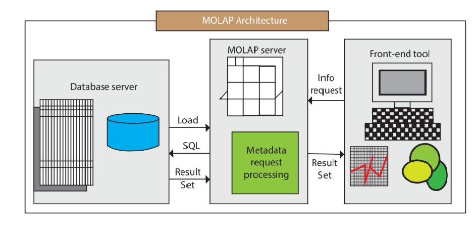

  (Image credit: https://www.javatpoint.com/data-warehouse-types-of-olap)

**2. ROLAP (Relational OLAP):**

**Advantages:**

- **Scalability:** ROLAP systems can handle very large datasets and are suitable for organizations with extensive data volumes.
- **Flexibility:** They work with existing relational database management systems (RDBMS), making them compatible with a wide range of data sources.
- **Data Integration:** ROLAP systems can seamlessly integrate with other business applications and processes.

**Disadvantages:**

- **Query Performance:** Analytical queries in ROLAP can be slower than MOLAP due to the relational nature of data storage.
- **Complexity:** Designing and maintaining ROLAP systems can be more complex, as they often require writing complex SQL queries.
- **Lack of Aggregation:** ROLAP systems may require more effort to create and manage aggregated data for performance optimization.

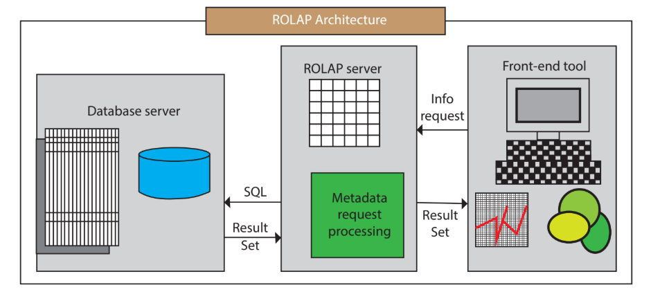

  (Image credit: https://www.javatpoint.com/data-warehouse-types-of-olap)

**3. HOLAP (Hybrid OLAP):**

HOLAP systems aim to combine the advantages of both MOLAP and ROLAP while mitigating their disadvantages. Here are some characteristics:

**Advantages:**

- **Combines Speed and Scalability:** HOLAP systems attempt to provide the query speed of MOLAP with the scalability of ROLAP.
- **Flexible Storage:** They allow for a mix of pre-aggregated and relational data storage, providing more flexibility in data management.
- **Adaptable to Varying Data Needs:** HOLAP can dynamically switch between storage modes based on query complexity.

**Disadvantages:**

- **Complex to Implement:** Setting up HOLAP systems can be more complex than MOLAP or ROLAP alone.
- **Potential Performance Trade-offs:** While HOLAP aims to balance speed and scalability, it may not achieve the same query performance as pure MOLAP systems.

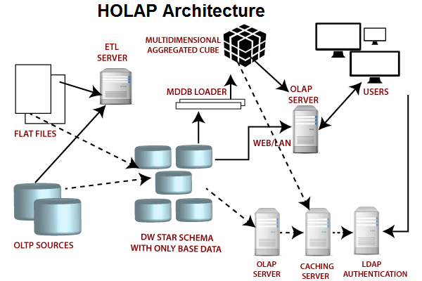

  (Image credit: https://www.javatpoint.com/data-warehouse-types-of-olap)

The choice between MOLAP, ROLAP, or HOLAP depends on an organization's specific requirements, data volume, query performance needs, and existing technology infrastructure. In practice, some organizations use a combination of these OLAP types to address different aspects of their analytical needs.

### OLAP operation

OLAP (Online Analytical Processing) operations are a set of data manipulation techniques used for querying and analyzing multidimensional data stored in OLAP databases or data cubes. These operations help users gain insights from large datasets quickly and effectively. There are several fundamental OLAP operations:

1. **Slice:** Slicing involves selecting a single dimension from a multidimensional cube to view a "slice" of the data. This operation allows users to focus on a specific dimension's values while keeping all other dimensions constant. For example, you can slice a sales data cube to view sales figures for a particular product category across different time periods.

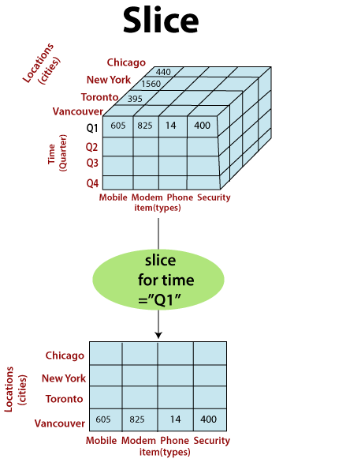

   (IMAGE CREDIT: https://www.javatpoint.com/olap-operations)
2. **Dice:** Dicing is similar to slicing but involves selecting specific values or ranges within multiple dimensions simultaneously. It allows users to create a subcube by specifying conditions for multiple dimensions. For instance, you could dice a data cube to examine sales data for a particular region, product category, and time frame.

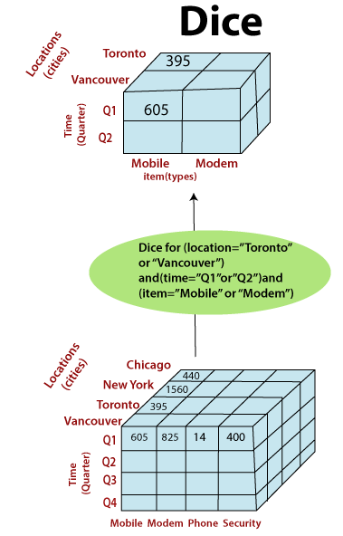

   (IMAGE CREDIT: https://www.javatpoint.com/olap-operations)
3. **Roll-up (Climb):** Roll-up involves aggregating data from a lower-level dimension to a higher-level dimension. It moves up the hierarchy to see summarized or aggregated data. For instance, you can roll up sales data from daily to monthly or yearly totals to get a broader perspective.

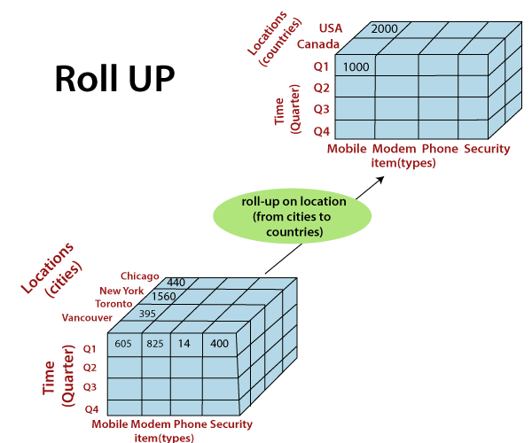

4. **Drill-down (Dig):** Drill-down is the opposite of roll-up. It involves breaking down aggregated data into more detailed levels. Users can explore data at finer granularity by drilling down. For example, you can drill down from yearly sales to monthly, weekly, or daily sales figures.

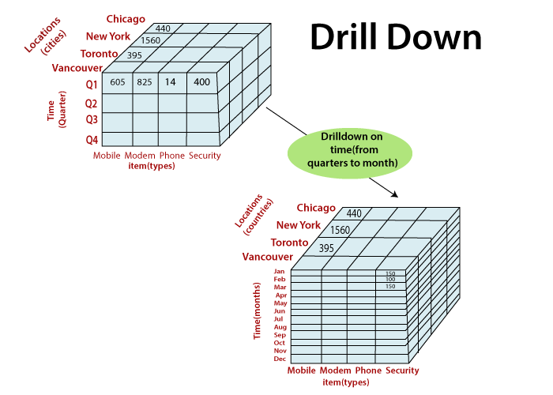

   (IMAGE CREDIT: https://www.javatpoint.com/olap-operations)
5. **Pivot (Rotate):** Pivoting reorients the data cube to view it from a different perspective. It involves swapping the dimensions, which can provide alternative views of the data. Pivoting can help users analyze data from various angles and dimensions.

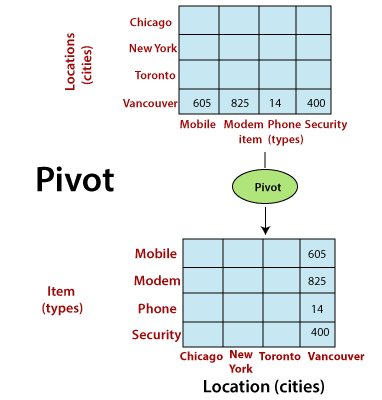

   (IMAGE CREDIT: https://www.javatpoint.com/olap-operations)
6. **Cross-tabulation (Pivot Table):** Cross-tabulation or pivot tables allow users to create two-dimensional tables from multidimensional data. It involves selecting two dimensions and aggregating data values in the intersecting cells. Cross-tabulations are useful for comparing data in a straightforward tabular format.
7. **Ranking and Sorting:** OLAP operations can also include ranking and sorting data based on specific measures or dimensions. This helps users identify top performers, outliers, or trends within the data.
8. **Calculations and Formulas:** OLAP systems often support custom calculations and formulas for creating derived measures or calculated members. These operations enable users to perform complex calculations on the data within the cube.
9. **Top N Analysis:** Top N analysis involves retrieving the top or bottom N items based on a specific measure. It is useful for identifying the best or worst performers within a dataset.
10. **Time Series Analysis:** OLAP operations can handle time-based data, allowing users to analyze data trends, seasonality, and anomalies over time.

These OLAP operations are essential for business intelligence, reporting, and decision support systems. They enable users to navigate and explore multidimensional data efficiently, making it easier to discover insights and make informed decisions. The specific operations and functionalities may vary depending on the OLAP system or tool being used.

## Warehouse dimensional modeling

- Warehouse dimensional modeling is a data modeling technique used to store and organize data in a data warehouse. It is a way of organizing data so that it is easy to query and analyze.
- It's particularly valuable when dealing with large datasets and complex business questions.
- Warehouse dimensional modeling is a powerful technique for storing and organizing data in a data warehouse. It makes it easy to query and analyze data, and it can be used to support a wide range of business intelligence and data warehousing applications.
- Warehouse dimensional modeling is based on the concept of **dimensions** and **facts**.
  - **Dimensions** These are attributes by which you want to analyze your data. Common dimensions include time, geography, product, customer, and more, depending on the domain.
    - Dimensions often have hierarchies. For example, a time dimension might have a hierarchy of Year > Quarter > Month > Day. Hierarchies enable drill-down analysis.
  - **Facts** are quantitative measurements of data, such as sales, inventory, and website traffic.

### Objectives of Dimensional Modeling

The purposes of dimensional modeling are:

- To produce database architecture that is easy for end-clients to understand and write queries.
- To maximize the efficiency of queries. It achieves these goals by minimizing the number of tables and relationships between them.

### Types of tables in dimensional modeling

In a warehouse dimensional model, data is stored in two types of tables:

- **Dimension tables:**
  - Each dimension table contains attributes related to that dimension. For example, a "Time" dimension might have attributes like Year, Quarter, Month, and Day.
  - Dimension tables are typically normalized, which means that they are organized in such a way that each attribute is only stored once.
- **Fact tables:**
  - These are measurable data points or metrics you want to analyze, such as sales revenue, quantity sold, or profit.
  - *foreign keys:* Fact tables typically contain *foreign keys* that link to dimension tables. These foreign keys establish relationships between dimensions and facts.
  - Contrary to dimension table, fact tables, are typically denormalized, which means that they may contain redundant data. This is done to improve query performance.

Dimension tables contain data about the dimensions, and fact tables contain data about the facts.

### Advantages of Dimensional Modeling

Here are some of the benefits of using warehouse dimensional modeling:

- **Improved query performance:** Warehouse dimensional models are designed for fast querying and analysis. This is because dimension tables are normalized and fact tables are denormalized.
- **Reduced data redundancy:** Warehouse dimensional models can help to reduce data redundancy by storing data in a single location. This can save storage space and improve data quality.
- **Improved data consistency:** Warehouse dimensional models can help to improve data consistency by enforcing referential integrity constraints between dimension tables and fact tables. This ensures that data is always accurate and up-to-date.
- **Improved data accessibility:** Warehouse dimensional models make it easy to access data from different sources. This is because dimension tables and fact tables are typically stored in a single database.

Warehouse dimensional modeling is a valuable technique for any organization that needs to store and analyze large amounts of data. It can help organizations to improve their business intelligence and data warehousing capabilities.

### Disadvantages of Dimensional Modeling

- To maintain the integrity of fact and dimensions, loading the data warehouses with a record from various operational systems is complicated.
- It is severe to modify the data warehouse operation if the organization adopting the dimensional technique changes the method in which it does business.

#### Example

Here are some examples of how warehouse dimensional modeling is used in the real world:

- **Retail:** Retailers use warehouse dimensional modeling to analyze customer data, product data, and sales data. This data can be used to improve customer targeting, product recommendations, and inventory management.
- **Finance:** Financial institutions use warehouse dimensional modeling to analyze customer data, transaction data, and market data. This data can be used to improve risk management, fraud detection, and investment decisions.
- **Healthcare:** Healthcare organizations use warehouse dimensional modeling to analyze patient data, medical research data, and clinical trial data. This data can be used to improve patient care, develop new treatments, and reduce costs.

  Warehouse dimensional modeling is a powerful technique that can be used to support a wide range of business applications.

[figure not shown]

### Steps to creat a dimensional data model

Dimensional data modeling is a key technique in data warehousing and analytics. Here are the basic steps to create a dimensional data model:

1. **Identify Business Requirements**: Begin by understanding the business needs and the questions you want to answer with your data model. This step is crucial as it guides the entire modeling process.
2. **Select Dimension and Fact Tables**: Identify the entities (dimensions) and the measurable data (facts) that are relevant to your analysis. Dimensions are attributes by which you want to analyze your data, while facts are the numerical data points you want to measure.
3. **Design Dimension Tables**:
   - Create dimension tables for each dimension identified in step 2. These tables contain attributes related to each dimension. For example, if you are modeling sales data, you might have a "Time" dimension with attributes like Year, Quarter, Month, etc.
   - Define hierarchies within dimensions, such as Year > Quarter > Month in the Time dimension.
4. **Design Fact Tables**:
   - Create fact tables that store the measures or metrics you want to analyze. These tables typically contain foreign keys to link to dimension tables.
   - Decide on the granularity of your fact table. This determines the level of detail at which data is recorded. For example, daily sales or monthly sales.
5. **Establish Relationships**: Define the relationships between dimension tables and fact tables using foreign keys. This linkage allows you to perform meaningful queries across different dimensions.
6. **Create a Star or Snowflake Schema**:
   - In a star schema, all dimension tables directly relate to the fact table. It's a simple and denormalized structure.
   - In a snowflake schema, dimension tables may be normalized, leading to a more complex but space-efficient structure.
7. **Populate Data**: Load data into your dimension and fact tables from various sources, such as databases or external files. Ensure data quality and consistency.
8. **Add Hierarchies and Aggregations**:
   - Create hierarchies in your dimension tables to facilitate drill-down analysis.
   - Pre-calculate aggregations like sums, averages, or counts in your fact table to improve query performance.
9. **Implement Business Logic**: Apply any required business rules or calculations to the data to meet specific analytical needs.
10. **Testing and Validation**: Thoroughly test your data model by running sample queries and ensuring the results match the expected outcomes.
11. **Documentation**: Document the structure of your dimensional data model, including definitions of dimensions, facts, hierarchies, and relationships. This documentation is crucial for future users.
12. **Optimization**: Continuously monitor and optimize the performance of your data model as the data volume grows or business requirements change.
13. **Usage and Reporting**: Finally, make the data model available to end-users through data visualization tools or analytics platforms for reporting and analysis.

Remember that dimensional modeling is highly dependent on the specific business context and data you're working with. Tailor your approach to meet the unique requirements of your projects, whether they are related to data science, data analytics, finance, or data engineering.

Main steps for dimensional modelling can be summarized as:

[figure not shown]

### Ways to structure data warehouse

There are several ways to structure a data warehouse, depending on the specific needs and requirements of the organization. Here are some common approaches to structuring a data warehouse:

1. **Star Schema:** The star schema is a widely used structure in data warehousing. It consists of a central fact table surrounded by multiple dimension tables. The fact table contains the measurements or facts of the business, such as sales or revenue, and the dimension tables provide context to these facts. Each dimension table represents a different aspect of the business, such as time, product, customer, or location. The star schema offers simplicity, ease of understanding, and efficient query performance.

[figure not shown]

(Image credit: https://en.wikipedia.org/wiki/Snowflake_schema)

1. **Snowflake Schema:** The snowflake schema is an extension of the star schema. It expands on the dimension tables by normalizing them into multiple levels. In a snowflake schema, dimension tables are connected through hierarchical relationships, resulting in a more complex structure. This schema can be useful when dealing with dimensions that have many attributes and hierarchies. However, it may require more complex query joins and can potentially impact performance.

[figure not shown]

(Image credit: https://en.wikipedia.org/wiki/Snowflake_schema)

1. **Fact Constellation (Galaxy) Schema:** The fact constellation schema, also known as the galaxy schema, is a more complex structure that consists of multiple fact tables sharing dimension tables. It is suitable when there are multiple fact tables representing different business processes or areas, but they share common dimensions. The fact constellation schema offers greater flexibility and can support complex analysis involving multiple fact tables.

[figure not shown]

(Image credit: https://www.geeksforgeeks.org/fact-constellation-in-data-warehouse-modelling/)

1. **Data Vault:** The Data Vault methodology is a modeling technique that focuses on scalability, flexibility, and historical tracking of data. It involves separating the data into three main types of tables: the hub tables representing core business entities, the satellite tables containing descriptive information about the hubs, and the link tables that capture the relationships between hubs. Data Vault structures are designed to handle large volumes of data, accommodate changes over time, and provide traceability of data.

[figure not shown]

(Image credit: https://blog.viadee.de/data-vault-nutzen-und-funktionsweise)

1. **Hybrid Approaches:** In practice, many data warehouses use a combination of different structures to meet specific needs. This can involve a mix of star schemas, snowflake schemas, and other modeling techniques. Hybrid approaches allow organizations to strike a balance between simplicity, performance, and flexibility by adopting different structures based on the specific requirements of different parts of the data warehouse.

The choice of data warehouse structure depends on factors such as the complexity of the data, the analytical requirements, the organization's reporting needs, and the scalability and performance considerations. It's important to carefully analyze the data and business requirements before determining the appropriate structure for a data warehouse.

### Types of Fact tables

Fact tables are a fundamental component of a star or snowflake schema in a data warehousing environment. They store quantitative data (measures) that can be analyzed and aggregated. There are several types of fact tables, each designed to serve a specific analytical purpose. Here are some common types of fact tables:

1. **Transaction Fact Table**:
   - Also known as a "detail" or "atomic" fact table, this type records individual transactions or events at the most granular level. It contains foreign keys to dimension tables and measures associated with each event. Transaction fact tables are used for detailed analysis and are the basis for aggregations in other fact tables.
2. **Snapshot Fact Table**:
   - A snapshot fact table captures data at specific points in time, often at regular intervals (e.g., daily, weekly, monthly). It's useful for tracking changes over time and creating historical reports. Examples include daily sales or inventory snapshots.
3. **Accumulating Snapshot Fact Table**:
   - This type of fact table is used to track a process that goes through well-defined stages. It records measures at each stage of the process and is updated as the process progresses. Commonly used in business processes, such as order fulfillment or project management.
4. **Periodic Snapshot Fact Table**:
   - Similar to the accumulating snapshot, but it records data at specific intervals (periods) rather than stages. It's often used for analyzing performance metrics, such as monthly sales or quarterly revenue.
5. **Factless Fact Table**:
   - A factless fact table contains only foreign keys to dimension tables and no measurable data (facts). It's used to represent events or relationships between dimensions. For example, it can be used to track student attendance, where the fact is the presence of a student in a class.
6. **Semi-additive Fact Table**:
   - Semi-additive fact tables contain measures that can be aggregated along some dimensions but not along others. For instance, you can sum up sales data by product but not by time because adding sales across time periods doesn't make sense.
7. **Non-additive Fact Table**:
   - Non-additive fact tables contain measures that cannot be aggregated at all. These measures are typically ratios, percentages, or other derived values. For example, profit margin or customer churn rate.
8. **Degenerate Dimension Fact Table**:
   - This type of fact table incorporates dimensions that are not represented in dimension tables because they don't provide additional information. Instead, they are included as attributes in the fact table. Common examples include transaction IDs and invoice numbers.
9. **Multi-fact Table**:
   - Multi-fact tables combine multiple measures from different fact tables into a single table. This is done to simplify querying and reporting when multiple measures are often used together.

The choice of which type of fact table to use depends on the specific analytical requirements of your data warehousing project. Different types of fact tables serve different purposes and are optimized for different types of queries and reporting.

### steps to create a fact table

Creating a fact table is a fundamental step in designing a data warehouse schema. Here are the steps to create a fact table:

1. **Define the Business Process or Analytical Objective**:
   - Start by understanding the business process or analytical objective that you want to model using the fact table. Determine what kind of measures (quantitative data) you need to track and analyze.
2. **Identify Dimensions**:
   - Identify the dimensions that are relevant to the business process. Dimensions are descriptive attributes that provide context to the measures in the fact table. For example, if you are tracking sales, dimensions might include time, product, store, and customer.
3. **Determine Grain**:
   - Define the grain or granularity of the fact table. This specifies the level of detail at which you want to record data. For example, in a sales fact table, you might choose to record sales at the daily, weekly, or monthly level.
4. **Select Measures**:
   - Determine the measures (facts) you want to store in the fact table. These are the quantitative values that you want to analyze. Common measures include sales revenue, quantity sold, cost, and profit.
5. **Design the Schema**:
   - Decide on the schema type for your data warehouse. Common schema types include star schema and snowflake schema. In a star schema, the fact table is at the center, surrounded by dimension tables. In a snowflake schema, dimension tables may be further normalized.
6. **Create the Fact Table**:
   - Using your chosen schema design, create the fact table in your data warehouse. Define the columns for the measures and foreign keys for the related dimension tables. Ensure that the fact table has a primary key.
7. **Load Data**:
   - Populate the fact table with data from your source systems. This may involve ETL (Extract, Transform, Load) processes to transform and clean the data before inserting it into the fact table.
8. **Establish Relationships**:
   - Create relationships between the fact table and dimension tables using foreign keys. These relationships enable you to join the fact table with dimension tables for analysis.
9. **Indexing and Partitioning**:
   - Depending on the size of your fact table and the query performance requirements, consider indexing and partitioning strategies. Indexes can improve query performance, while partitioning can help manage large fact tables.
10. **Testing and Validation**:
    - Thoroughly test the fact table by running sample queries and ensuring that the data is accurate and consistent with your business requirements. Validate that the aggregations and calculations work as expected.
11. **Documentation**:
    - Document the fact table structure, relationships with dimension tables, and the meaning of each measure. This documentation is essential for the understanding and maintenance of the data warehouse.
12. **Maintenance and Updates**:
    - As your data warehouse evolves, you may need to update and maintain the fact table. This includes adding new data, handling changes in source systems, and ensuring data quality.
13. **Access Control**:
    - Implement access control and security measures to restrict access to the fact table based on user roles and permissions.

Creating a fact table is a critical step in building an effective data warehouse that supports business intelligence and analytics. Properly designed and maintained fact tables are key to extracting valuable insights from your data.

#### Example

Let's create a fact table for a fictional retail business to track sales data. We'll go through the steps of creating the fact table using this example:

**Step 1: Define the Business Process**

- Our business process is to track and analyze sales data. We want to understand how much revenue we generate from the sales of various products in different stores over time.

**Step 2: Identify Dimensions**

- Dimensions for our sales fact table include:
  - Time (Date of the sale)
  - Product (Product ID, Name, Category)
  - Store (Store ID, Name, Location)
  - Customer (Customer ID, Name)

**Step 3: Determine Grain**

- We'll record sales data at the daily level, so our grain is daily sales.

**Step 4: Select Measures**

- Measures we want to include in our fact table:
  - Sales Amount (Revenue generated from each sale)
  - Quantity Sold (Number of products sold in each transaction)

**Step 5: Design the Schema**

- In this example, we'll use a star schema. The fact table will be at the center, surrounded by dimension tables (Time, Product, Store, Customer).

**Step 6: Create the Fact Table**

- Our fact table, let's call it `SALES_FACT`, is created with the following columns:
  - `SaleID` (Primary Key)
  - `DateKey` (Foreign Key to Time Dimension)
  - `ProductKey` (Foreign Key to Product Dimension)
  - `StoreKey` (Foreign Key to Store Dimension)
  - `CustomerKey` (Foreign Key to Customer Dimension)
  - `SalesAmount` (Numeric)
  - `QuantitySold` (Numeric)

[output not shown]

**Step 7: Load Data**

- Populate the `SALES_FACT` table with data from source systems. This involves extracting data from various sources, transforming it (e.g., data cleansing, data type conversions), and loading it into the fact table.

**Step 8: Establish Relationships**

- Create relationships between the fact table (`SALES_FACT`) and dimension tables (e.g., `TIME_DIM`, `PRODUCT_DIM`, `STORE_DIM`, `CUSTOMER_DIM`) using foreign keys. These relationships enable us to join the fact table with dimension tables for analysis.

**Step 9: Indexing and Partitioning**

- Depending on the size of the fact table, consider adding indexes on foreign key columns for performance optimization. You may also partition the fact table by time to manage large volumes of data efficiently.

**Step 10: Testing and Validation**

- Perform thorough testing by running sample queries and ensuring that data is accurate and consistent. Validate that aggregations and calculations (e.g., total revenue) work as expected.

**Step 11: Documentation**

- Document the structure of the `SALES_FACT` table, including column descriptions and relationships with dimension tables. Explain the meaning of each measure to aid in understanding and maintenance.

**Step 12: Maintenance and Updates**

- Regularly update the `SALES_FACT` table with new sales data as it becomes available. Ensure that historical data remains accessible and accurate.

**Step 13: Access Control**

- Implement access control and security measures to restrict access to the fact table based on user roles and permissions to protect sensitive data.

By following these steps and using the example of a sales fact table, you can create a structured and well-designed fact table that supports analytics and reporting for your retail business.

### Natural and surrogate keys

Natural keys and surrogate keys are two different types of primary keys used in database design to uniquely identify records in a table. They serve similar purposes but are based on different principles.

**1. Natural Key:**

- A natural key is a primary key that is derived from the actual data attributes of the record, typically a meaningful and unique piece of data.
- Natural keys are based on real-world data that is inherent to the entity being represented in the table.
- For example, in an "Employee" table, the employee's Social Security Number (SSN) or Employee ID could be used as a natural key if they are unique for each employee.

  **Pros of Natural Keys:**
  - They are meaningful and can provide context to the data.
  - No need to introduce an additional identifier.

    **Cons of Natural Keys:**
  - They can change over time (e.g., employee name changes), which can be problematic for historical data.
  - They may not be suitable for all situations, such as when data lacks a clear natural key.

**2. Surrogate Key:**

- A surrogate key is an artificial primary key created specifically for the purpose of uniquely identifying records in a table.
- Surrogate keys have no inherent meaning and are typically implemented as auto-incremented integers or GUIDs (Globally Unique Identifiers).
- They are not related to any natural data attributes of the entity.

  **Pros of Surrogate Keys:**
  - They are stable and do not change, making them ideal for historical data or situations where natural keys are subject to change.
  - They provide better performance for indexing and joining tables because they are typically smaller and faster to compare than complex natural keys.
  - They eliminate the need to rely on potentially sensitive or confidential data (e.g., SSN) as the primary identifier.

    **Cons of Surrogate Keys:**
  - They lack inherent meaning and context, which can make data less intuitive to understand.
  - In some cases, they may require an additional lookup to retrieve related real-world information.

In practice, the choice between natural keys and surrogate keys depends on the specific requirements of the database design and the nature of the data being stored. Many databases use a combination of both, where a surrogate key is used as the primary key for internal database operations, while a natural key is retained for external reference and reporting purposes. This hybrid approach combines the advantages of both types of keys.